# Machine Learning with R

### Factors are used to represent caterorical data. One can think of a ,

### factor as an integer vector where each integer has a label.

Using factors with labels is better than using integers because factors are self-describing. Have a variable that has values “Male” and “Female” is better than 1 and 2.

```r
data_heart        <- database
data_heart$target <- as.factor(data_heart$target)

database$sex                           <- factor(database$sex, levels=c(0, 1), labels=c("female", "male"), ordered = TRUE)
database$chest_pain_type               <- factor(database$chest_pain_type, levels=c(0, 1, 2, 3), labels=c("typical angina", "atypical angina", "non-anginal pain", "asymptomatic"), ordered = TRUE)
database$fasting_blood_sugar           <- factor(database$fasting_blood_sugar, levels=c(0, 1), labels=c(FALSE, TRUE), ordered = TRUE)
database$resting_cardiographic_results <- factor(database$resting_cardiographic_results, levels=c(0, 1, 2), labels=c("normal", "having wave abnormality", "probable ventricular hypertrophy"), ordered = TRUE )
database$exercise_induced_angina       <- factor(database$exercise_induced_angina, levels=c(0, 1), labels=c("No", "Yes"), ordered = TRUE)
database$slope_peak_exercise           <- factor(database$slope_peak_exercise, levels=c(0, 1, 2), labels=c("upsloping", "flat", "downsloping"), ordered = TRUE)
database$number_major_vessels          <- as.numeric(database$number_major_vessels)
database$thal                          <- as.numeric(database$thal)

database$target                        <- factor(database$target, levels=c(0, 1), labels=c("absence", "presence"), ordered = TRUE)
```

STR

```r
str(database)
```

```
## 'data.frame':    303 obs. of  14 variables:
##  $ age                             : int  63 37 41 56 57 57 56 44 52 57 ...
##  $ sex                             : Ord.factor w/ 2 levels "female"<"male": 2 2 1 2 1 2 1 2 2 2 ...
##  $ chest_pain_type                 : Ord.factor w/ 4 levels "typical angina"<..: 4 3 2 2 1 1 2 2 3 3 ...
##  $ resting_blood_pressure          : int  145 130 130 120 120 140 140 120 172 150 ...
##  $ serum_cholestoral               : int  233 250 204 236 354 192 294 263 199 168 ...
##  $ fasting_blood_sugar             : Ord.factor w/ 2 levels "FALSE"<"TRUE": 2 1 1 1 1 1 1 1 2 1 ...
##  $ resting_cardiographic_results   : Ord.factor w/ 3 levels "normal"<"having wave abnormality"<..: 1 2 1 2 2 2 1 2 2 2 ...
##  $ maximum_heart_rate              : int  150 187 172 178 163 148 153 173 162 174 ...
##  $ exercise_induced_angina         : Ord.factor w/ 2 levels "No"<"Yes": 1 1 1 1 2 1 1 1 1 1 ...
##  $ depression_induced_exercise_rest: num  2.3 3.5 1.4 0.8 0.6 0.4 1.3 0 0.5 1.6 ...
##  $ slope_peak_exercise             : Ord.factor w/ 3 levels "upsloping"<"flat"<..: 1 1 3 3 3 2 2 3 3 3 ...
##  $ number_major_vessels            : num  0 0 0 0 0 0 0 0 0 0 ...
##  $ thal                            : num  1 2 2 2 2 1 2 3 3 2 ...
##  $ target                          : Ord.factor w/ 2 levels "absence"<"presence": 2 2 2 2 2 2 2 2 2 2 ...
```

Summary

```r
summary(database)
```

```
##       age            sex              chest_pain_type
##  Min.   :29.00   female: 96   typical angina  :143
##  1st Qu.:47.50   male  :207   atypical angina : 50
##  Median :55.00                non-anginal pain: 87
##  Mean   :54.37                asymptomatic    : 23
##  3rd Qu.:61.00
##  Max.   :77.00
##  resting_blood_pressure serum_cholestoral fasting_blood_sugar
##  Min.   : 94.0          Min.   :126.0     FALSE:258
##  1st Qu.:120.0          1st Qu.:211.0     TRUE : 45
##  Median :130.0          Median :240.0
##  Mean   :131.6          Mean   :246.3
##  3rd Qu.:140.0          3rd Qu.:274.5
##  Max.   :200.0          Max.   :564.0
##                   resting_cardiographic_results maximum_heart_rate
##  normal                          :147           Min.   : 71.0
##  having wave abnormality         :152           1st Qu.:133.5
##  probable ventricular hypertrophy:  4           Median :153.0
##                                                 Mean   :149.6
##                                                 3rd Qu.:166.0
##                                                 Max.   :202.0
##  exercise_induced_angina depression_induced_exercise_rest
##  No :204                 Min.   :0.00
##  Yes: 99                 1st Qu.:0.00
##                          Median :0.80
##                          Mean   :1.04
##                          3rd Qu.:1.60
##                          Max.   :6.20
##   slope_peak_exercise number_major_vessels      thal            target
##  upsloping  : 21      Min.   :0.0000       Min.   :0.000   absence :138
##  flat       :140      1st Qu.:0.0000       1st Qu.:2.000   presence:165
##  downsloping:142      Median :0.0000       Median :2.000
##                       Mean   :0.7294       Mean   :2.314
##                       3rd Qu.:1.0000       3rd Qu.:3.000
##                       Max.   :4.0000       Max.   :3.000
```

### 10º Step - Outlier detection and treatment

Outliers in data can distort predictions and affect the accuracy, if you don’t detect and handle them appropriately especially in regression models. Why outliers treatment is important? Because, it can drastically bias/change the fit estimates and predictions. A handy explanation of Outiliers it can be found in : https://www.r-bloggers.com/outlier-detection-and-treatment-with-r/

### 10.1º Step - Detect Outliers - Univariate approach

For a given continuous variable, outliers are those observations that lie outside 1.5 * IQR, where IQR, the ‘Inter Quartile Range’ is the difference between 75th and 25th quartiles. Look at the points outside the whiskers in below box plot.

Age

```r
summary(database$age)
```

```
##    Min. 1st Qu.  Median    Mean 3rd Qu.    Max.
##   29.00   47.50   55.00   54.37   61.00   77.00
```

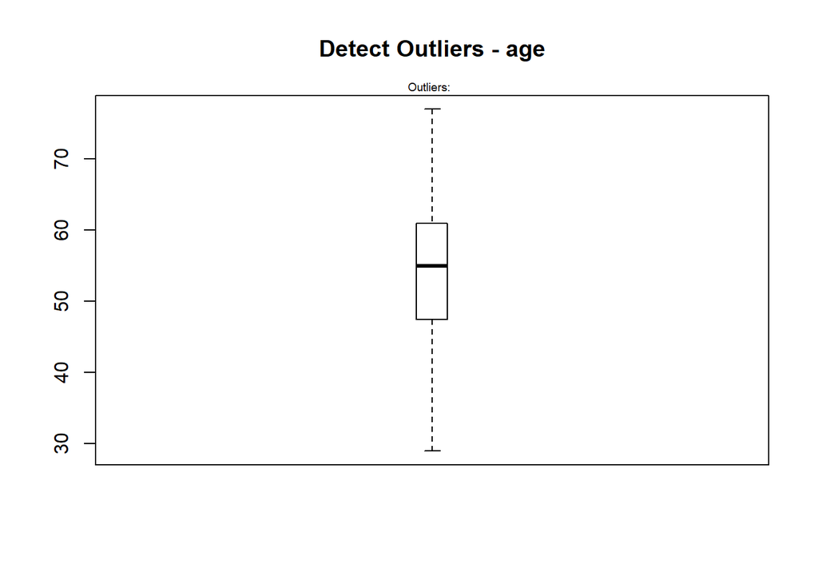

```r
outlier_values <- boxplot.stats(database$age)$out          # outlier values.
boxplot(database$age, main="Detect Outliers - age", boxwex=0.1)
mtext(paste("Outliers: ", paste(outlier_values, collapse=", ")), cex=0.6)
```

Sex

```r
summary(database$sex)
```

```
## female   male
##     96    207
```

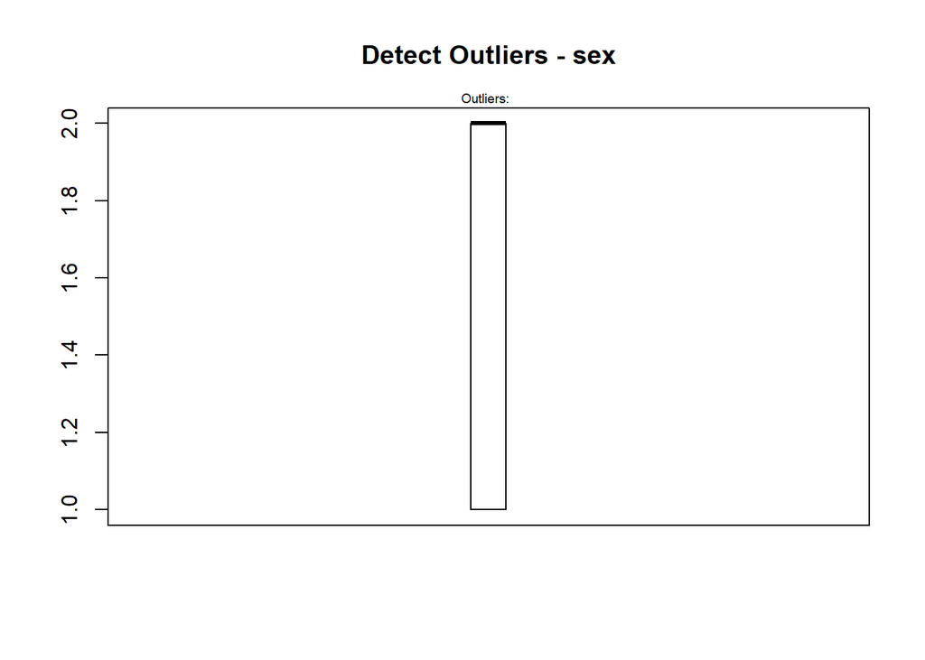

```r
outlier_values <- boxplot.stats(database$sex)$out          # outlier values.
boxplot(database$sex, main="Detect Outliers - sex", boxwex=0.1)
mtext(paste("Outliers: ", paste(outlier_values, collapse=", ")), cex=0.6)
```

Chest pain type

```r
summary(database$chest_pain_type)
```

```
##   typical angina  atypical angina non-anginal pain     asymptomatic
##              143               50               87               23
```

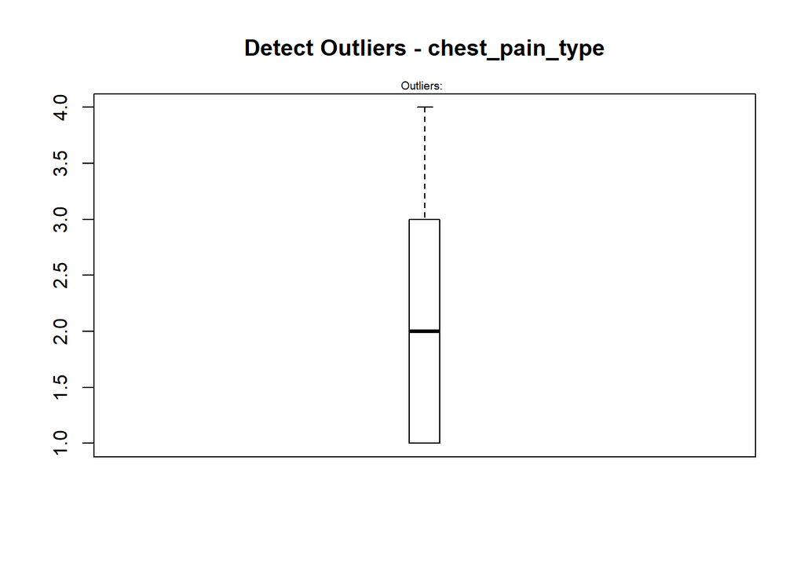

```r
outlier_values <- boxplot.stats(database$chest_pain_type)$out          # outlier values.
boxplot(database$chest_pain_type, main="Detect Outliers - chest_pain_type", boxwex=0.1)
mtext(paste("Outliers: ", paste(outlier_values, collapse=", ")), cex=0.6)
```

Resting blood pressure

```r
summary(database$resting_blood_pressure)
```

```
##    Min. 1st Qu.  Median    Mean 3rd Qu.    Max.
##    94.0   120.0   130.0   131.6   140.0   200.0
```

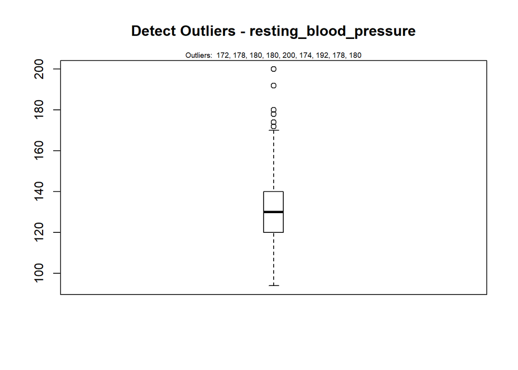

```r
outlier_values <- boxplot.stats(database$resting_blood_pressure)$out          # outlier values.
boxplot(database$resting_blood_pressure, main="Detect Outliers - resting_blood_pressure", boxwex=0.1)
mtext(paste("Outliers: ", paste(outlier_values, collapse=", ")), cex=0.6)
```

Serum cholestoral

```r
summary(database$serum_cholestoral)
```

```
##    Min. 1st Qu.  Median    Mean 3rd Qu.    Max.
##   126.0   211.0   240.0   246.3   274.5   564.0
```

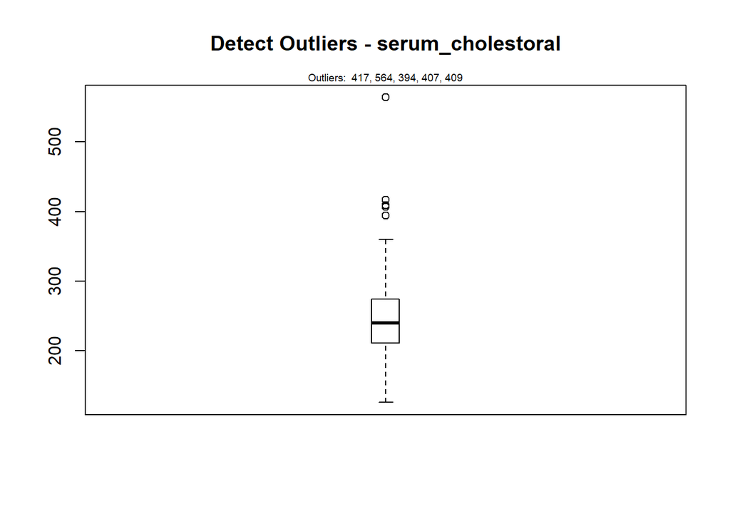

```r
outlier_values <- boxplot.stats(database$serum_cholestoral)$out          # outlier values.
boxplot(database$serum_cholestoral, main="Detect Outliers - serum_cholestoral", boxwex=0.1)
mtext(paste("Outliers: ", paste(outlier_values, collapse=", ")), cex=0.6)
```

Fasting blood sugar

```r
summary(database$fasting_blood_sugar)
```

```
## FALSE  TRUE
##   258    45
```

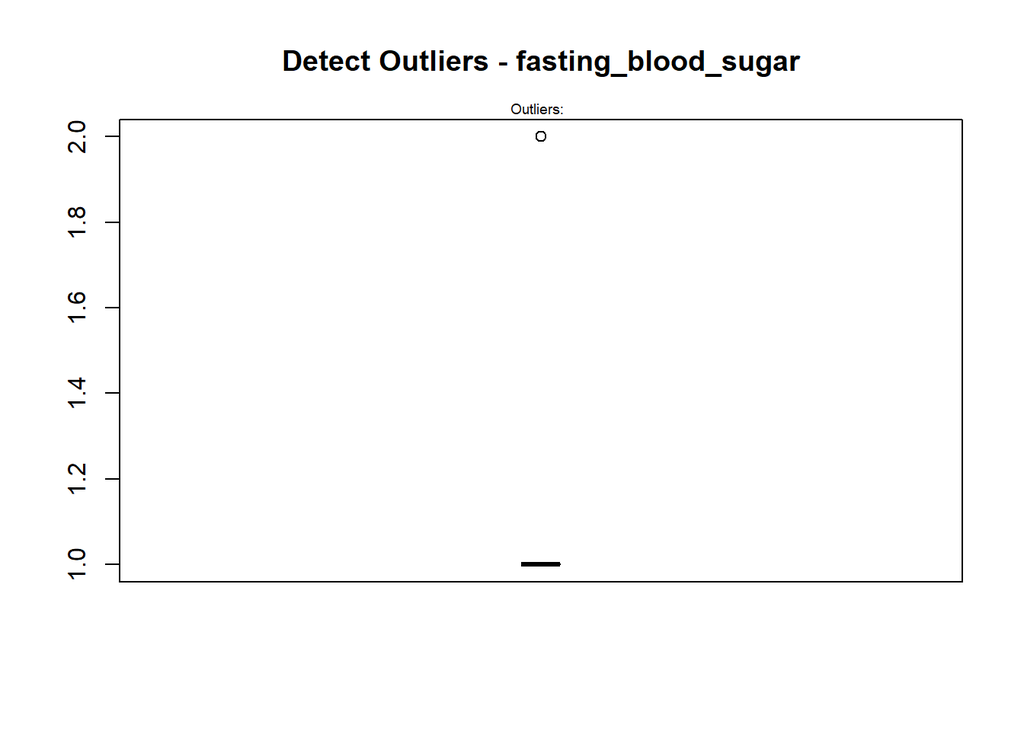

```r
outlier_values <- boxplot.stats(database$fasting_blood_sugar)$out          # outlier values.
boxplot(database$fasting_blood_sugar, main="Detect Outliers - fasting_blood_sugar", boxwex=0.1)
mtext(paste("Outliers: ", paste(outlier_values, collapse=", ")), cex=0.6)
```

Resting cardiographic results

```r
summary(database$resting_cardiographic_results)
```

```
##                           normal          having wave abnormality
##                              147                              152
## probable ventricular hypertrophy
##                                4
```

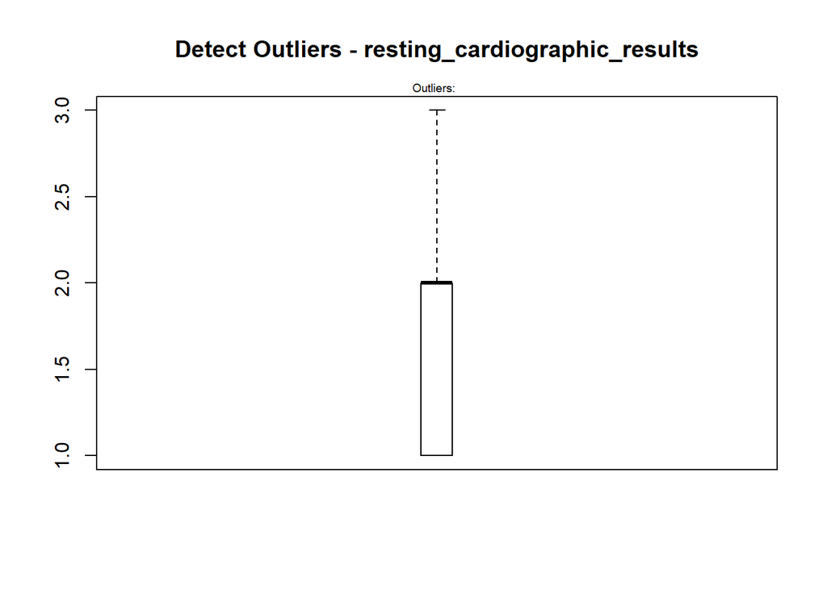

```r
outlier_values <- boxplot.stats(database$resting_cardiographic_results)$out          # outlier values.
boxplot(database$resting_cardiographic_results, main="Detect Outliers - resting_cardiographic_results", boxwex=0.1)
mtext(paste("Outliers: ", paste(outlier_values, collapse=", ")), cex=0.6)
```

Maximum heart rate

```r
summary(database$maximum_heart_rate)
```

```
##    Min. 1st Qu.  Median    Mean 3rd Qu.    Max.
##    71.0   133.5   153.0   149.6   166.0   202.0
```

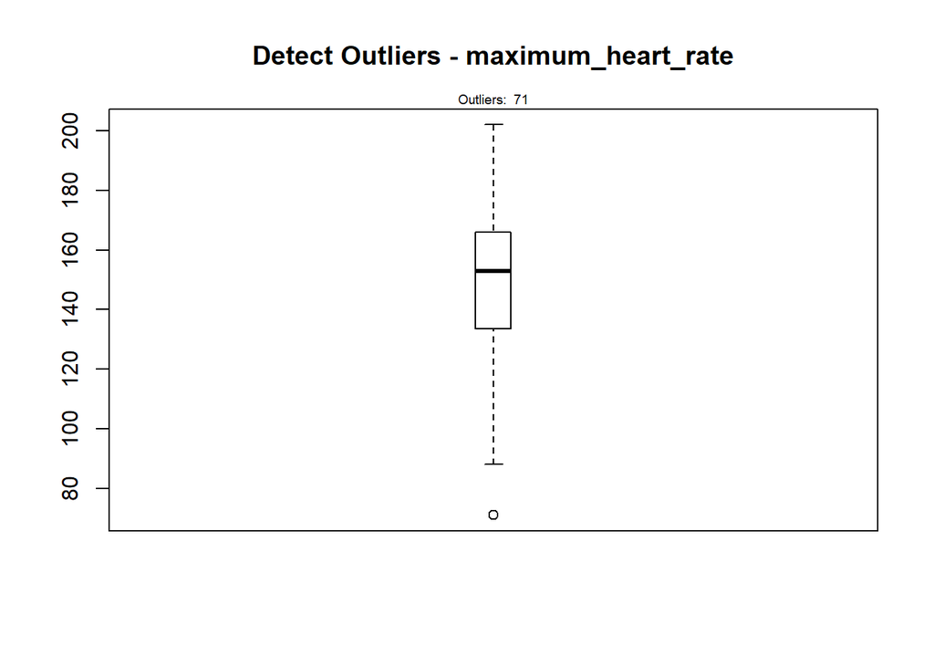

```r
outlier_values <- boxplot.stats(database$maximum_heart_rate)$out          # outlier values.
boxplot(database$maximum_heart_rate, main="Detect Outliers - maximum_heart_rate", boxwex=0.1)
mtext(paste("Outliers: ", paste(outlier_values, collapse=", ")), cex=0.6)
```

Exercise induced angina

```r
summary(database$exercise_induced_angina)
```

```
##  No Yes
## 204  99
```

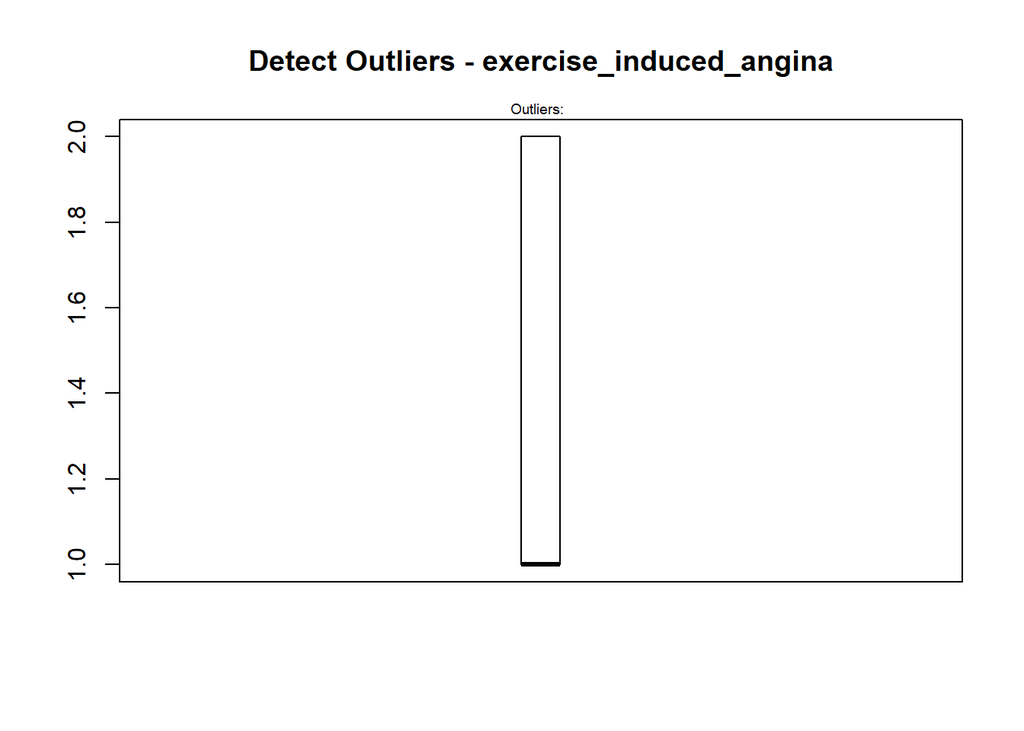

```r
outlier_values <- boxplot.stats(database$exercise_induced_angina)$out          # outlier values.
boxplot(database$exercise_induced_angina, main="Detect Outliers - exercise_induced_angina", boxwex=0.1)
mtext(paste("Outliers: ", paste(outlier_values, collapse=", ")), cex=0.6)
```

Depression induced exercise rest

```r
summary(database$depression_induced_exercise_rest)
```

```
##    Min. 1st Qu.  Median    Mean 3rd Qu.    Max.
##    0.00    0.00    0.80    1.04    1.60    6.20
```

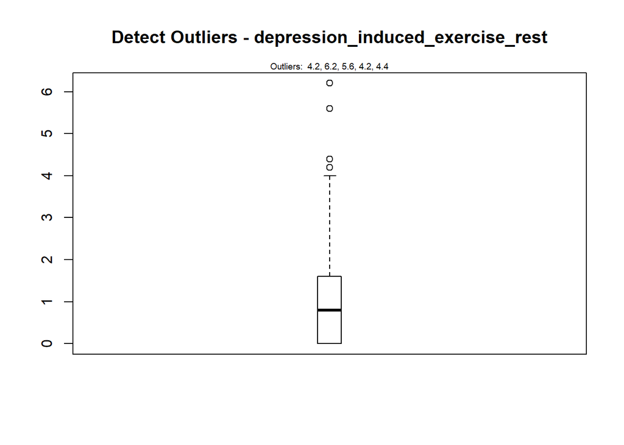

```r
outlier_values <- boxplot.stats(database$depression_induced_exercise_rest)$out          # outlier values.
boxplot(database$depression_induced_exercise_rest, main="Detect Outliers - depression_induced_exercise_rest", boxwex=0.1)
mtext(paste("Outliers: ", paste(outlier_values, collapse=", ")), cex=0.6)
```

Slope peak exercise

```r
summary(database$slope_peak_exercise)
```

```
##   upsloping        flat downsloping
##          21         140         142
```

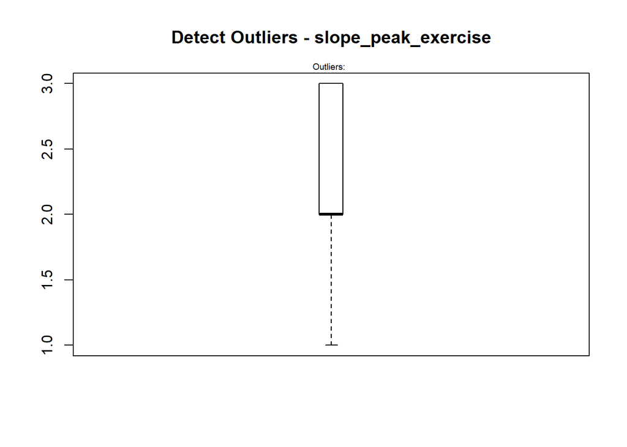

```r
outlier_values <- boxplot.stats(database$slope_peak_exercise)$out          # outlier values.
boxplot(database$slope_peak_exercise, main="Detect Outliers - slope_peak_exercise", boxwex=0.1)
mtext(paste("Outliers: ", paste(outlier_values, collapse=", ")), cex=0.6)
```

Number major vessels

```r
summary(database$number_major_vessels)
```

```
##    Min. 1st Qu.  Median    Mean 3rd Qu.    Max.
##  0.0000  0.0000  0.0000  0.7294  1.0000  4.0000
```

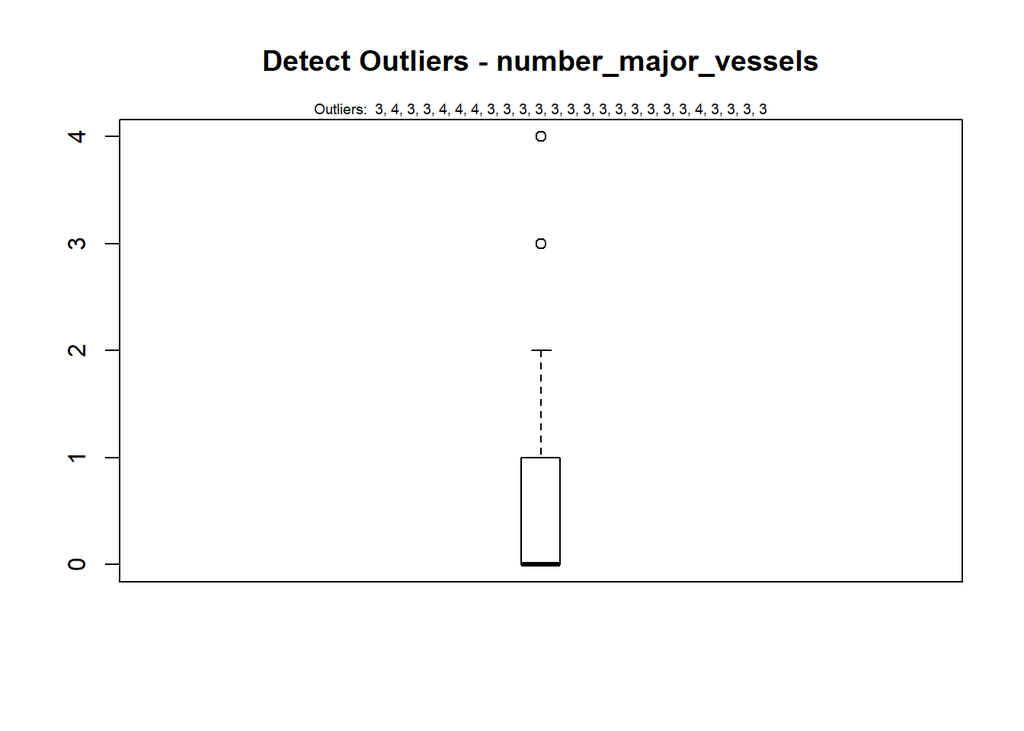

```r
outlier_values <- boxplot.stats(database$number_major_vessels)$out          # outlier values.
boxplot(database$number_major_vessels, main="Detect Outliers - number_major_vessels", boxwex=0.1)
mtext(paste("Outliers: ", paste(outlier_values, collapse=", ")), cex=0.6)
```

thal

```r
summary(database$thal)
```

```
##    Min. 1st Qu.  Median    Mean 3rd Qu.    Max.
##   0.000   2.000   2.000   2.314   3.000   3.000
```

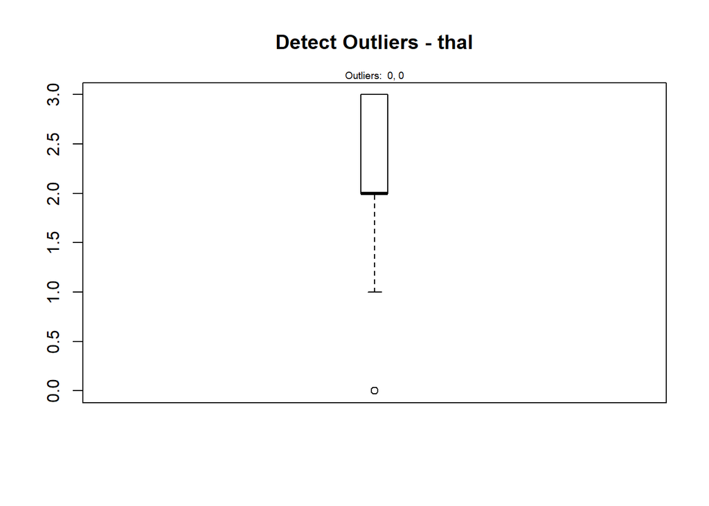

```r
outlier_values <- boxplot.stats(database$thal)$out          # outlier values.
boxplot(database$thal, main="Detect Outliers - thal", boxwex=0.1)
mtext(paste("Outliers: ", paste(outlier_values, collapse=", ")), cex=0.6)
```

Target

```r
summary(database$target)
```

```
##  absence presence
##      138      165
```

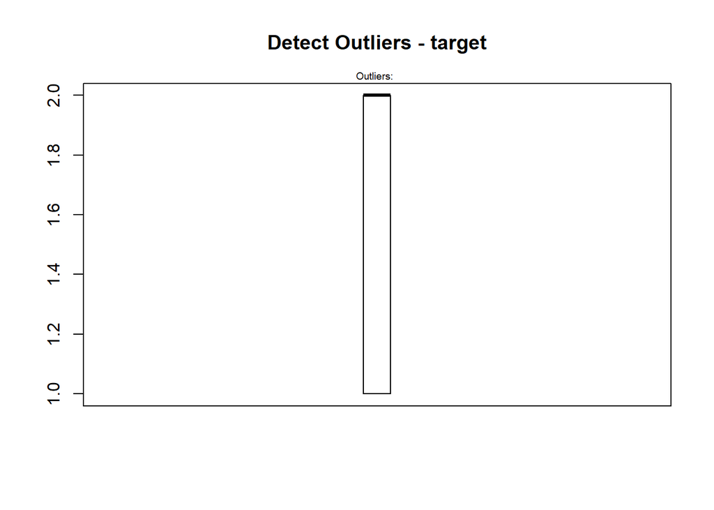

```r
outlier_values <- boxplot.stats(database$target)$out          # outlier values.
boxplot(database$target, main="Detect Outliers - target", boxwex=0.1)
mtext(paste("Outliers: ", paste(outlier_values, collapse=", ")), cex=0.6)
```

### 10.2º Step - We found Outliers only for following continuous variable:

Let’s to try a bivariate approach, so that we can visualize in box-plot of the X and Y, for categorical X’ (target).

Resting blood pressure

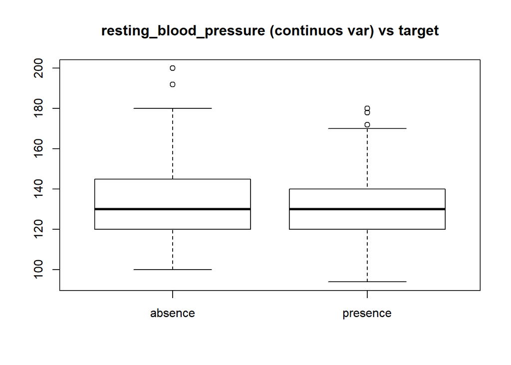

```r
boxplot(resting_blood_pressure ~ target, data=database, main="resting_blood_pressure (continuos var) vs target")
```

Serum cholestoral

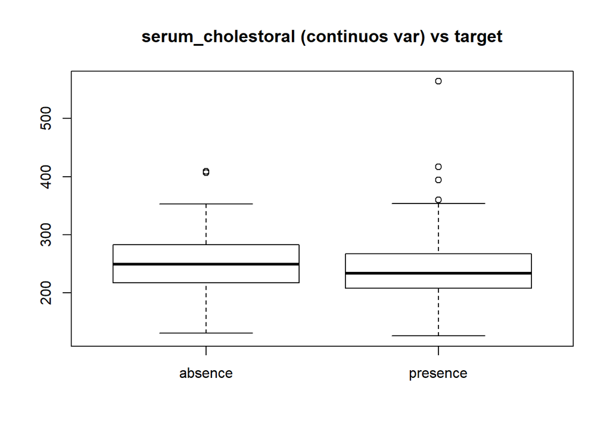

```r
boxplot(serum_cholestoral ~ target, data=database, main="serum_cholestoral (continuos var) vs target")
```

Maximum heart Rate

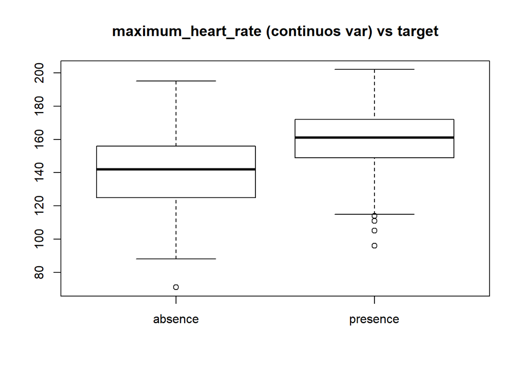

```r
boxplot(maximum_heart_rate ~ target, data=database, main="maximum_heart_rate (continuos var) vs target")
```

Depression induced exercise rest

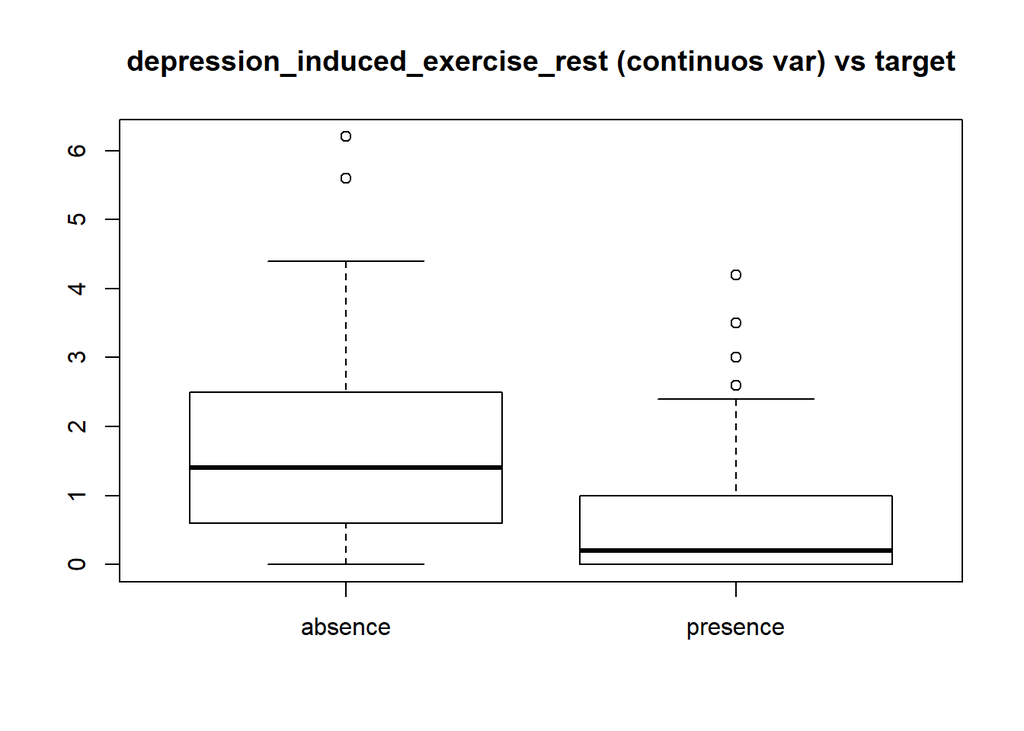

```r
boxplot(depression_induced_exercise_rest ~ target, data=database, main="depression_induced_exercise_rest (continuos var) vs target")
```

### 11º Step - Identification Of Near Zero Variance Predictors.

It diagnoses predictors that have one unique value (i.e. are zero variance predictors) or predictors that are have both of the following characteristics: they have very few unique values relative to the number of samples and the ratio of the frequency of the most common value to the frequency of the second most common value is large

```r
table(nearZeroVar(data_heart))
```

```
## < table of extent 0 >
```

### 12º Step - Exploratory Data Analysis.

Statistical Methods for Exploratory Analysis. Theses methods include clustering and dimension reduction techiques. It comes to visualization a high dimensional or multidimensional data. Clustering organizes things that are close into groups. Probably, the most kind of familiar distance metric is the Euclidean distance which is just kind of the stright-line distance between any two points.

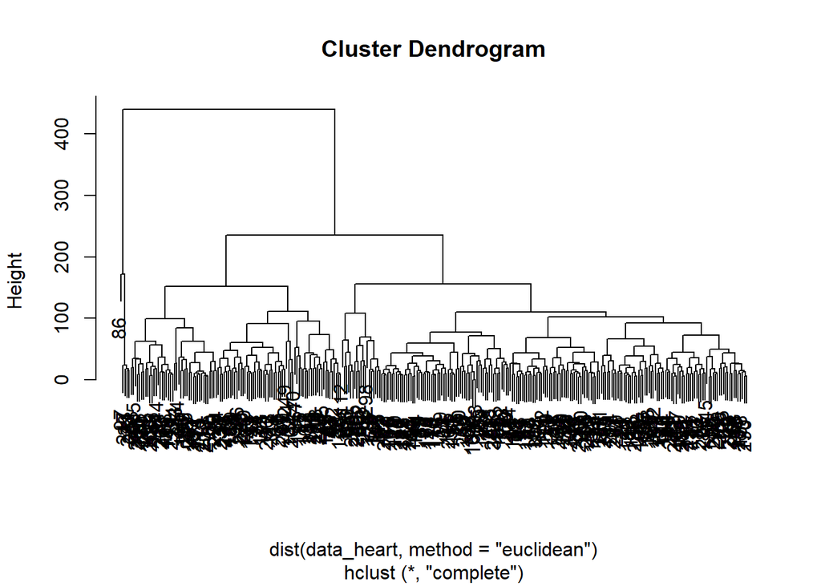

```r
hc <- hclust(dist(data_heart, method = "euclidean"), method="complete")
plot(hc)
```

Hierarchical Clustering give us an ideia of the relationship between variables or observation.

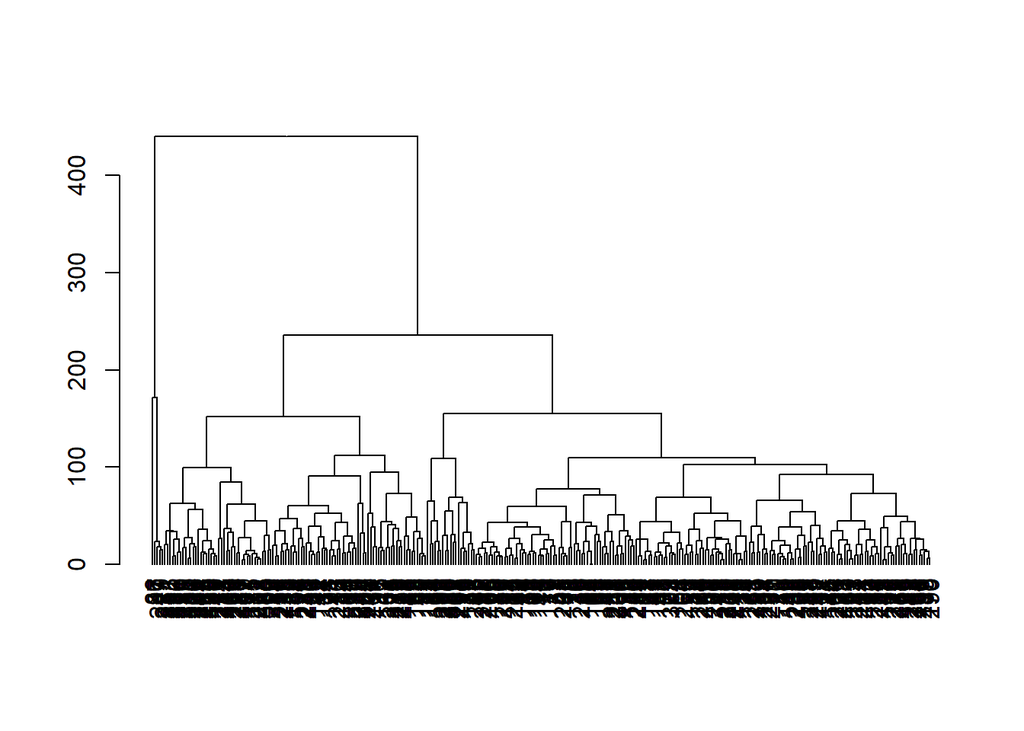

```r
plot(as.dendrogram(hc))
```

### 13º Step - Analytic Graphics.

They help us find patterns in data and understand its properties. They suggest modeling strategies to communicate results. - Show Comparisons. - Show causality, mechanism, explanation, systematic structure. - Shom multivariate data. - Integrate multiple models of evidence.

```r
png('plot_machine_learning.png')
```

```r
par(mfrow=c(2,2))
```

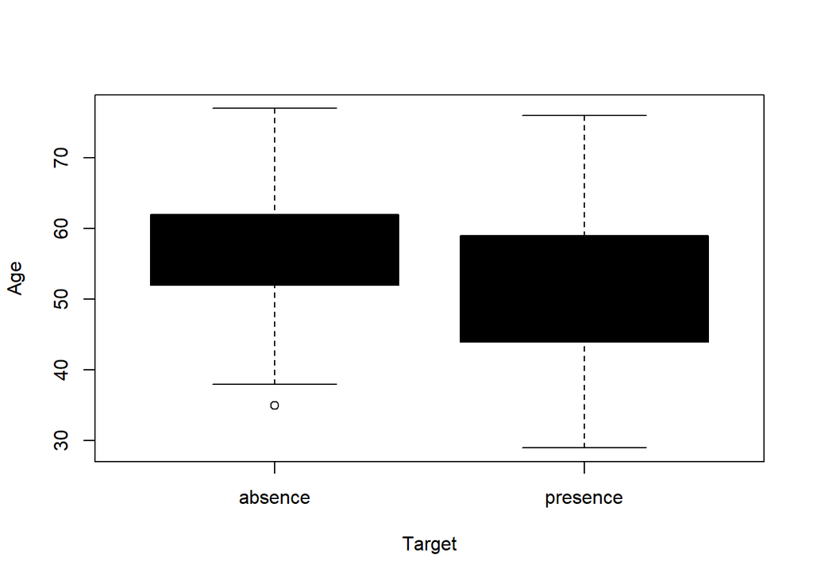

```r
plot(x = database$target, y = database$age, col = "black", type = "l", xlab = "Target", ylab = "Age", plot = TRUE)
```

[figure not shown]

```r
plot(x = database$target, y = database$sex, col = "black", type = "l",  xlab = "Target", ylab = "Sex", plot = TRUE)
```

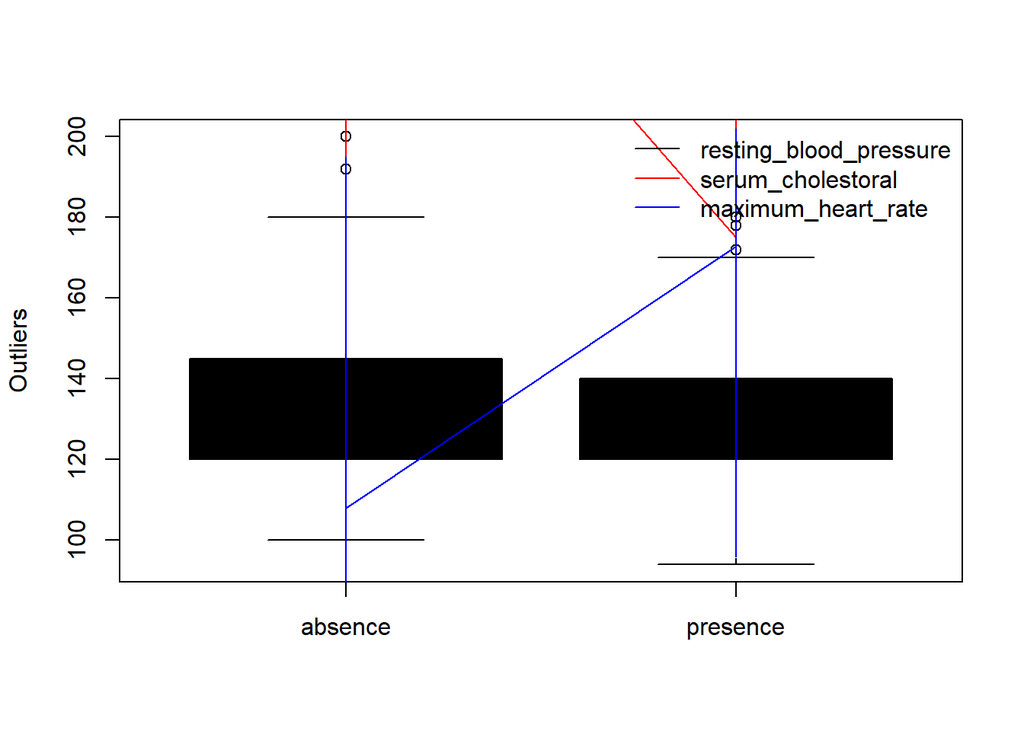

```r
plot(x = database$target , y = database$resting_blood_pressure, col = "black", type = "l", xlab = "", ylab = "Outliers", plot = TRUE)
lines(x = database$target, y = database$serum_cholestoral, col = "red")
lines(x = database$target, y = database$maximum_heart_rate, col = "blue")
legend("topright", lty = "solid", col = c("black", "red", "blue"), legend = c("resting_blood_pressure", "serum_cholestoral", "maximum_heart_rate"), bty = "n")
```

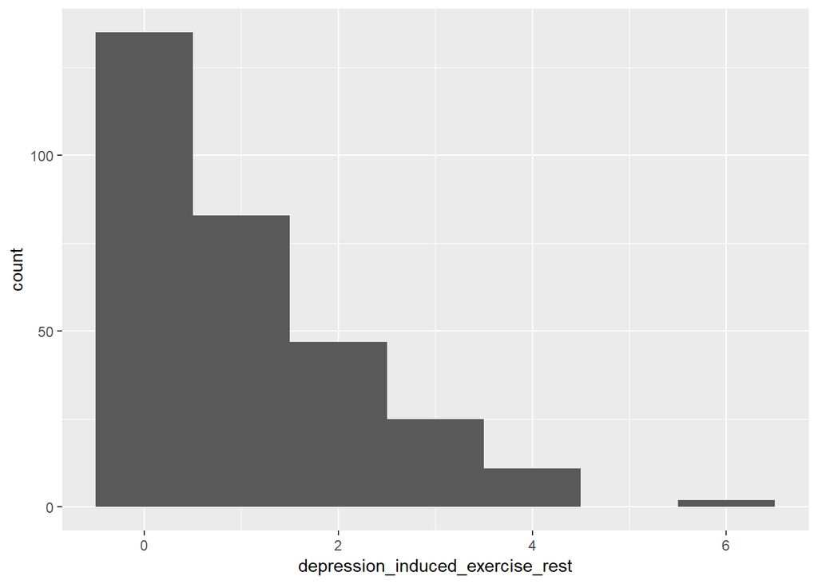

```r
df <- select(data_heart, target, depression_induced_exercise_rest)
ggplot(df, aes(x=depression_induced_exercise_rest)) + geom_histogram(binwidth=1)
```

### 14º Step - Setting Random number seed with Set.seed ensure reproducibility.

Always set the random number seed when conducting a simulation.

```r
set.seed(1)
```

### 15º Step - The training set is used to fit the models;

The test set is used for assessment of the generalization error of the final chosen model. Ideally, the test set should be kept in a “vault,” and be brought out only at the end of the data analysis. It generates randomly the indices for test base. We split out 30% for testing and 70% for training.

```r
indexes = sample(1:nrow(data_heart), size=0.3*nrow(data_heart))
```

```r
train = data_heart[-indexes,]
test = data_heart[indexes,]
```

### 16º Step - SVM - Support Vector Machines

- cost or C => Cost of the violations of the restrictions. (constant of Lagrange’s regularization)
- Gamma => It defines the distance of influence of the patterns in the limits of decision (low values => far, high values => near)

```r
system.time(svm_model <- svm(target ~., train, probability =T))
```

```
##    user  system elapsed
##    0.11    0.00    0.11
```

```r
predictionsSVM <- predict(svm_model, test, probability =T)
table(predictionsSVM,test$target)
```

```
##
## predictionsSVM  0  1
##              0 33  6
##              1 10 41
```

```r
acuracy = 1 - mean(predictionsSVM != test$target)
acuracy
```

```
## [1] 0.8222222
```

```r
summary(svm_model)
```

```
##
## Call:
## svm(formula = target ~ ., data = train, probability = T)
##
##
## Parameters:
##    SVM-Type:  C-classification
##  SVM-Kernel:  radial
##        cost:  1
##       gamma:  0.07692308
##
## Number of Support Vectors:  132
##
##  ( 67 65 )
##
##
## Number of Classes:  2
##
## Levels:
##  0 1
```

```r
probabilities = attr(predictionsSVM, "probabilities")
predictionsAndProbabilities = cbind(test$target, predictionsSVM, probabilities)
View(predictionsAndProbabilities)
```

Metric that evaluates the level of agreement of a classification task

```r
cm = table(predictionsSVM,test$target); cm
```

```
##
## predictionsSVM  0  1
##              0 33  6
##              1 10 41
```

```r
kappa = confusionMatrix(cm)$overall[2]; kappa
```

```
##     Kappa
## 0.6423249
```

Confusion MatriX

```r
confusionMatrix(cm)
```

```
## Confusion Matrix and Statistics
##
##
## predictionsSVM  0  1
##              0 33  6
##              1 10 41
##
##                Accuracy : 0.8222
##                  95% CI : (0.7274, 0.8948)
##     No Information Rate : 0.5222
##     P-Value [Acc > NIR] : 2.711e-09
##
##                   Kappa : 0.6423
##
##  Mcnemar's Test P-Value : 0.4533
##
##             Sensitivity : 0.7674
##             Specificity : 0.8723
##          Pos Pred Value : 0.8462
##          Neg Pred Value : 0.8039
##              Prevalence : 0.4778
##          Detection Rate : 0.3667
##    Detection Prevalence : 0.4333
##       Balanced Accuracy : 0.8199
##
##        'Positive' Class : 0
##
```

### 17º Step - Decision Tree

```r
system.time(tree_model <- tree(target ~., train))
```

```
##    user  system elapsed
##    0.01    0.00    0.02
```

```r
predictionsDtree <- predict(tree_model, test, type = "class")
table(predictionsDtree, test$target)
```

```
##
## predictionsDtree  0  1
##                0 34 12
##                1  9 35
```

```r
acuracy = 1 - mean(predictionsDtree != test$target)
acuracy
```

```
## [1] 0.7666667
```

```r
summary(tree_model)
```

```
##
## Classification tree:
## tree(formula = target ~ ., data = train)
## Variables actually used in tree construction:
## [1] "number_major_vessels"             "thal"
## [3] "maximum_heart_rate"               "exercise_induced_angina"
## [5] "depression_induced_exercise_rest" "serum_cholestoral"
## [7] "age"                              "chest_pain_type"
## Number of terminal nodes:  18
## Residual mean deviance:  0.3997 = 77.94 / 195
## Misclassification error rate: 0.1033 = 22 / 213
```

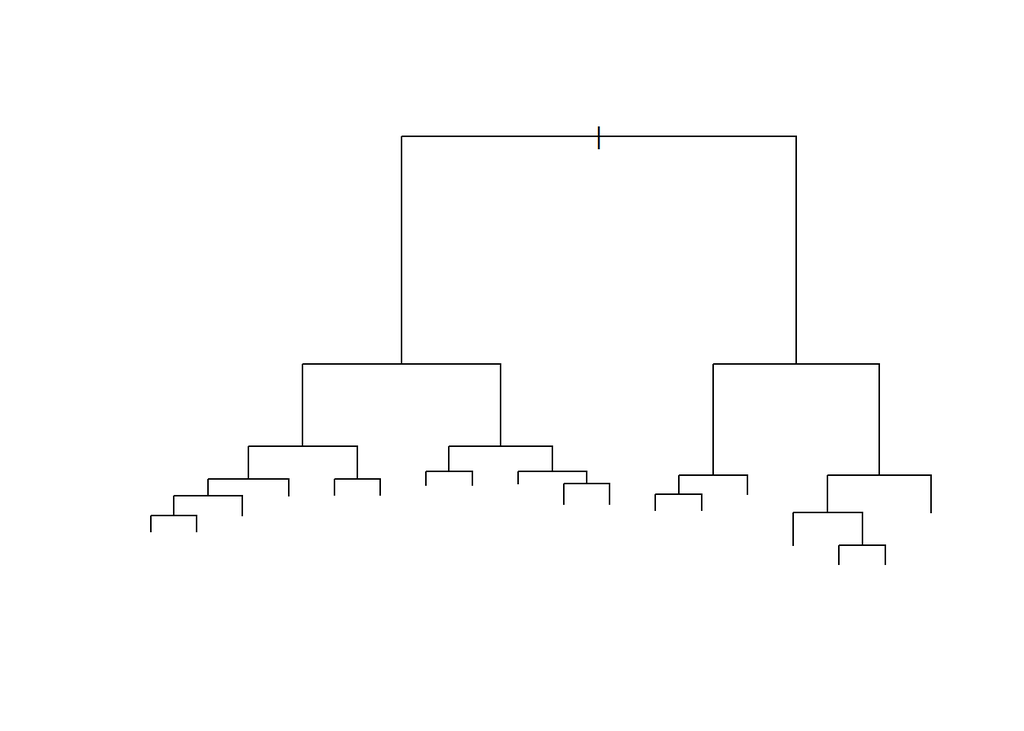

```r
plot(tree_model)
```

Metric that evaluates the level of agreement of a classification task

```r
cm = table(predictionsDtree,test$target); cm
```

```
##
## predictionsDtree  0  1
##                0 34 12
##                1  9 35
```

```r
kappa = confusionMatrix(cm)$overall[2]; kappa
```

```
##     Kappa
## 0.5337938
```

Confusion MatriX

```r
confusionMatrix(cm)
```

```
## Confusion Matrix and Statistics
##
##
## predictionsDtree  0  1
##                0 34 12
##                1  9 35
##
##                Accuracy : 0.7667
##                  95% CI : (0.6657, 0.8494)
##     No Information Rate : 0.5222
##     P-Value [Acc > NIR] : 1.559e-06
##
##                   Kappa : 0.5338
##
##  Mcnemar's Test P-Value : 0.6625
##
##             Sensitivity : 0.7907
##             Specificity : 0.7447
##          Pos Pred Value : 0.7391
##          Neg Pred Value : 0.7955
##              Prevalence : 0.4778
##          Detection Rate : 0.3778
##    Detection Prevalence : 0.5111
##       Balanced Accuracy : 0.7677
##
##        'Positive' Class : 0
##
```

### 18º Step - Random Forest

```r
system.time(forest_model <- randomForest(target ~., data = train,
                                         importance = TRUE,
                                         do.trace = 100))
```

```
## ntree      OOB      1      2
##   100:  16.43% 24.21% 10.17%
##   200:  15.96% 24.21%  9.32%
##   300:  15.96% 22.11% 11.02%
##   400:  15.02% 22.11%  9.32%
##   500:  16.43% 23.16% 11.02%
```

```
##    user  system elapsed
##    0.59    0.03    0.62
```

```r
predictionsForest = predict(forest_model, test)
table(predictionsForest, test$target)
```

```
##
## predictionsForest  0  1
##                 0 33  8
##                 1 10 39
```

```r
acuracy = 1 - mean(predictionsForest != test$target)
acuracy
```

```
## [1] 0.8
```

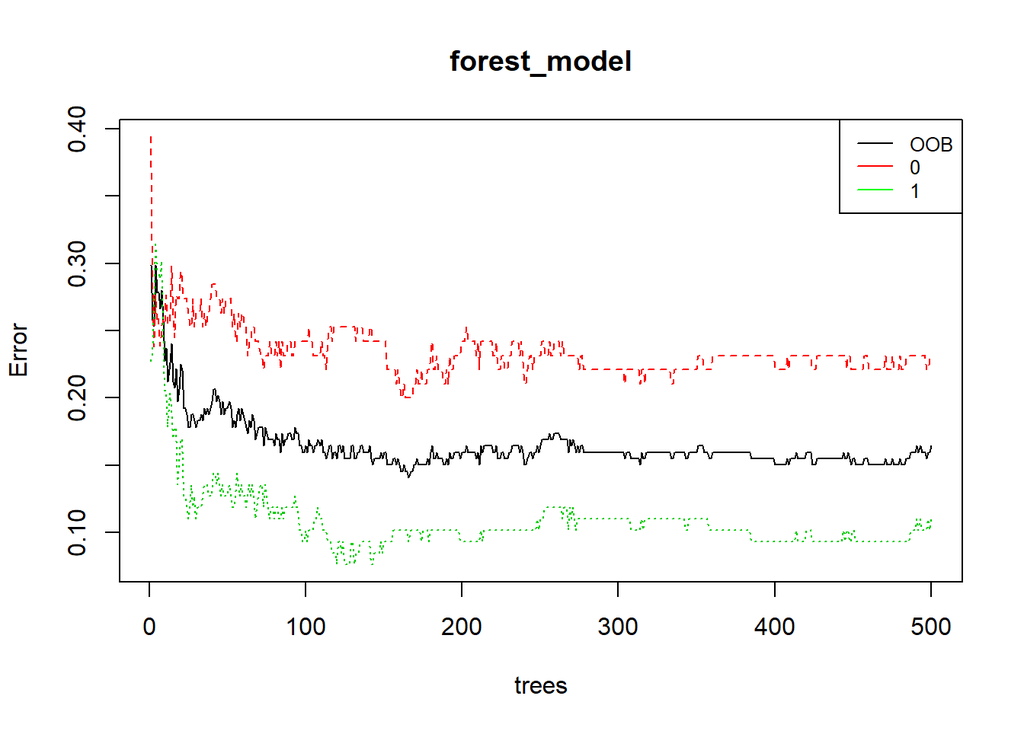

```r
plot(forest_model)
legend("topright", legend=c("OOB", "0", "1"),
       col=c("black", "red", "green"), lty=1:1, cex=0.8)
```

Two measures of importance to rank attributes.

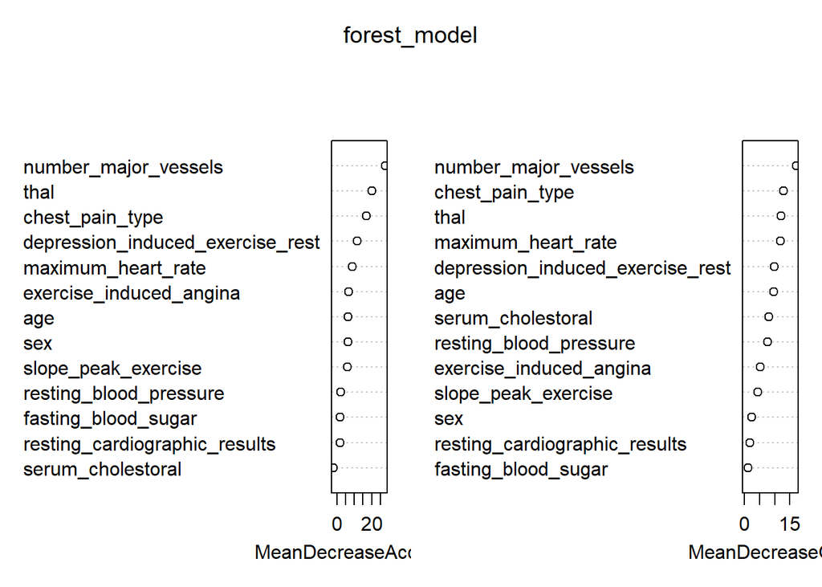

```r
varImpPlot(forest_model)
```

Metric that evaluates the level of agreement of a classification task

```r
cm = table(predictionsForest,test$target); cm
```

```
##
## predictionsForest  0  1
##                 0 33  8
##                 1 10 39
```

```r
kappa = confusionMatrix(cm)$overall[2]; kappa
```

```
##     Kappa
## 0.5984135
```

Confusion MatriX

```r
confusionMatrix(cm)
```

```
## Confusion Matrix and Statistics
##
##
## predictionsForest  0  1
##                 0 33  8
##                 1 10 39
##
##                Accuracy : 0.8
##                  95% CI : (0.7025, 0.8769)
##     No Information Rate : 0.5222
##     P-Value [Acc > NIR] : 4.197e-08
##
##                   Kappa : 0.5984
##
##  Mcnemar's Test P-Value : 0.8137
##
##             Sensitivity : 0.7674
##             Specificity : 0.8298
##          Pos Pred Value : 0.8049
##          Neg Pred Value : 0.7959
##              Prevalence : 0.4778
##          Detection Rate : 0.3667
##    Detection Prevalence : 0.4556
##       Balanced Accuracy : 0.7986
##
##        'Positive' Class : 0
##
```

### 19º Step - Principal Component Analysis (PCA)

The principal components are equal to the right singular values if you first scale(Subtract the mean, divide by the standard deviation) the variables. We do not use the “target” column when pca is applied.

```r
train_pca <- train[-14]
train_pca <- scale(train_pca)
pca <- princomp(train_pca)
summary(pca)
```

```
## Importance of components:
##                           Comp.1    Comp.2    Comp.3     Comp.4     Comp.5
## Standard deviation     1.6640231 1.2209697 1.1144255 1.09137052 1.03006301
## Proportion of Variance 0.2140026 0.1152153 0.0959848 0.09205446 0.08200267
## Cumulative Proportion  0.2140026 0.3292179 0.4252027 0.51725718 0.59925984
##                            Comp.6     Comp.7     Comp.8     Comp.9
## Standard deviation     0.96735647 0.92389158 0.85801991 0.84872924
## Proportion of Variance 0.07232251 0.06596938 0.05689775 0.05567224
## Cumulative Proportion  0.67158235 0.73755173 0.79444949 0.85012173
##                           Comp.10    Comp.11    Comp.12    Comp.13
## Standard deviation     0.80293715 0.69923889 0.65288376 0.61592998
## Proportion of Variance 0.04982686 0.03778779 0.03294368 0.02931994
## Cumulative Proportion  0.89994859 0.93773638 0.97068006 1.00000000
```

Pca’s results (standard deviation, proportional variance and proportion of cumulative variance)

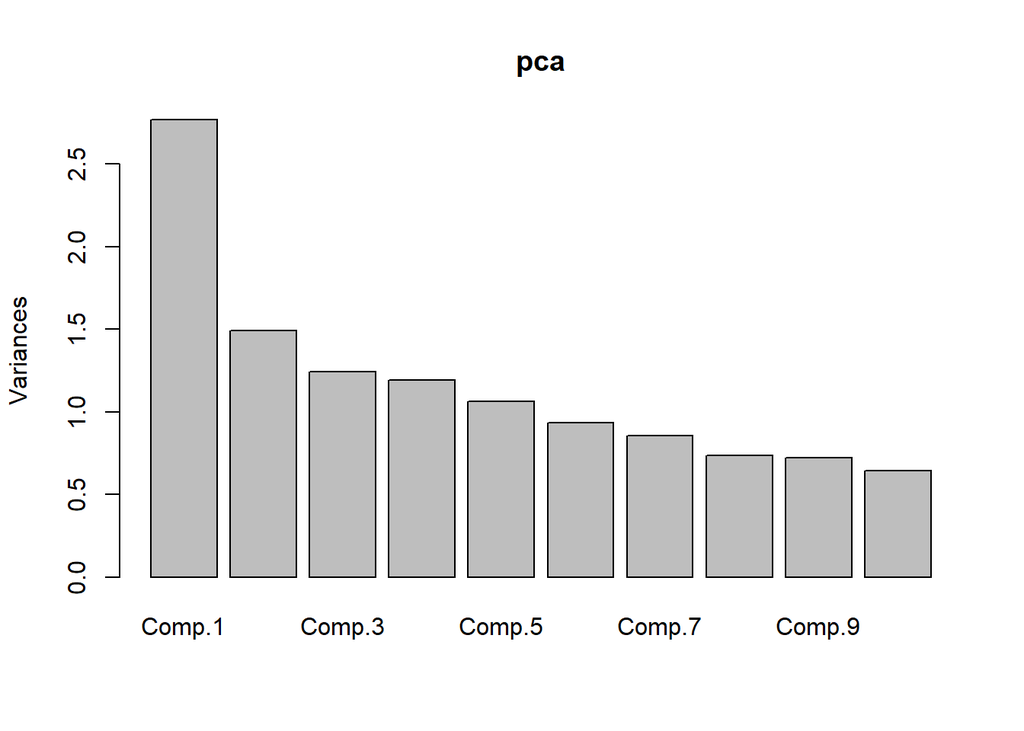

```r
plot(pca)
```

### 19.1º Step - Principal Component Analysis (PCA)

```r
vars <- pca$sdev^2
vars <- vars/sum(vars)
cumulativeVariance <- cumsum(vars)
```

```r
View(as.data.frame(cumulativeVariance))
```

```r
train_pca <- pca$scores[,1:11]
train_pca = as.data.frame(train_pca)
train_pca = cbind(train_pca, train$target)
colnames(train_pca)[ncol(train_pca)] <- "target"
```

### 20º Step - SVM - Support Vector Machines + PCA

```r
system.time(svm_model_pca <- svm(target ~., train_pca, probability =T))
```

```
##    user  system elapsed
##    0.09    0.00    0.09
```

```r
predictionsSVM_PCA <- predict(svm_model_pca, train_pca, probability =T)
table(predictionsSVM_PCA,train_pca$target)
```

```
##
## predictionsSVM_PCA   0   1
##                  0  86   6
##                  1   9 112
```

```r
acuracy = 1 - mean(predictionsSVM_PCA != train_pca$target)
acuracy
```

```
## [1] 0.9295775
```

```r
summary(svm_model_pca)
```

```
##
## Call:
## svm(formula = target ~ ., data = train_pca, probability = T)
##
##
## Parameters:
##    SVM-Type:  C-classification
##  SVM-Kernel:  radial
##        cost:  1
##       gamma:  0.09090909
##
## Number of Support Vectors:  138
##
##  ( 68 70 )
##
##
## Number of Classes:  2
##
## Levels:
##  0 1
```

```r
probabilities = attr(predictionsSVM_PCA, "probabilities")
predictionsAndProbabilities = cbind(test$target, predictionsSVM_PCA, probabilities)
View(predictionsAndProbabilities)
```

Metric that evaluates the level of agreement of a classification task

```r
cm = table(predictionsSVM_PCA,train_pca$target); cm
```

```
##
## predictionsSVM_PCA   0   1
##                  0  86   6
##                  1   9 112
```

```r
kappa = confusionMatrix(cm)$overall[2]; kappa
```

```
##     Kappa
## 0.8570534
```

Confusion MatriX

```r
confusionMatrix(cm)
```

```
## Confusion Matrix and Statistics
##
##
## predictionsSVM_PCA   0   1
##                  0  86   6
##                  1   9 112
##
##                Accuracy : 0.9296
##                  95% CI : (0.8865, 0.9601)
##     No Information Rate : 0.554
##     P-Value [Acc > NIR] : <2e-16
##
##                   Kappa : 0.8571
##
##  Mcnemar's Test P-Value : 0.6056
##
##             Sensitivity : 0.9053
##             Specificity : 0.9492
##          Pos Pred Value : 0.9348
##          Neg Pred Value : 0.9256
##              Prevalence : 0.4460
##          Detection Rate : 0.4038
##    Detection Prevalence : 0.4319
##       Balanced Accuracy : 0.9272
##
##        'Positive' Class : 0
##
```